# birp

Understanding whether a population is **declining, stable, or increasing** is a crucial part of effective biodiversity management and policy decisions. Many ecological time‑series are short, noisy, and/or collected with different survey methods, making it difficult to use approaches that demand large data sets or highly standardized survey designs.

`birp` implements **hierarchical Bayesian models** designed to overcome these limitations, providing a flexible framework that allows you to **test for population trends** and **changes in trends** under various **study designs** (e.g. **Before‑After, Control‑Intervention, BACI**).

This vignette demonstrates how to:

- Getting started: **Fit a basic trend model** using example data
- **Include specific study designs**, such as before-after (BA) or control-intervention (CI) setups
- **Combine data** from different survey methods to estimate a shared trend
- Fit a **negative-binomial model** when your data is overdispersed
- Fit a **stochastic trend model** when you expect random variability between different survey locations
- **Add covariates** that account for survey effort or detection probability to improve model accuracy
- **Understand the modeling approach** behind `birp` and how it works

This vignette focuses on the **practical use** of the `birp` R-package; for the full **methodological details**, **simulation studies**, and **real‑world case analyses**, please refer to the [accompanying manuscript](https://www.biorxiv.org/content/10.1101/2025.01.08.631844v1).

# Getting Started with `birp`

This section guides you through a **simple analysis workflow** using the `birp` package, from generating data to visualizing results. Let’s start by **loading the package**:

```r
library(birp)
```

## Input Data Format

`birp` expects a data frame with five required columns:

- `location` : site identifier
- `timepoint` : time of observation (e.g., year, but can be any numbers that make sense to you)
- `counts` : number of detections (e.g., number of individuals observed)
- `effort` : sampling effort (e.g., number of trap nights). Can be named *covEffort_1*, *covEffort_2*, … if multiple covariates are used.
- `CI_group` : group assignment (e.g., “control” or “intervention”)

If your study has no intervention, like in this first example, you can assign the same group name (e.g., `Group_1`) to all rows. Each data set/input file should correspond to a **single survey method**. If your study used multiple survey methods, `birp` can analyze all methods together; this will be covered in a later section.

Here’s an example data set:

```
>    location timepoint counts effort CI_group
> 1     site1      2020     28      2  Group_1
> 2     site1      2021     12      1  Group_1
> 3     site1      2022     26      2  Group_1
> 4     site1      2023     48      3  Group_1
> 5     site1      2024     20      1  Group_1
> 6     site2      2020     21      1  Group_1
> 7     site2      2021     22      1  Group_1
> 8     site2      2022     76      4  Group_1
> 9     site2      2023     22      1  Group_1
> 10    site2      2024    100      4  Group_1
> 11    site3      2020     65      5  Group_1
> 12    site3      2021     32      2  Group_1
> 13    site3      2022     60      5  Group_1
> 14    site3      2023     19      1  Group_1
> 15    site3      2024     42      2  Group_1
```

In this example, there are **three different survey locations** (site1, site2, and site3) that have been sampled over the course of **five years** (2020-2024). The effort numbers could represent, for example, the **number of camera trap days** of that given location and timepoint. Note that you **do not need to have data from every year** to be able to use birp! There is no before/after or control/intervention design here; therefore every row has been assigned `Group_1`. You can create this data frame by copying and pasting this command into your R-console:

```r
# Create example data
exampleData <- data.frame(
  location = rep(c("site1", "site2", "site3"), each = 5),
  timepoint = rep(2020:2024, times = 3),
  counts    = c(28, 12, 26, 48, 20, 21, 22, 76, 22, 100, 65, 32, 60, 19, 42),
  effort   = c(2,1,2,3,1,1,1,4,1,4,5,2,5,1,2),
  CI_group    = rep("Group_1", times = 15)
)
```

## Preparing your data

Once you prepared your data set, the next step is to **convert it into a `birp_data` object**, which is the required format for analysis using the `birp` package. There are **three functions** available for creating a `birp_data` object, depending on the format and source of your input data:

- `birp_data_from_data_frame()` Use this function when your data is already loaded into R as a *data.frame*. It allows you to specify columns corresponding to location, timepoint, counts, control-intervention group (CI_group) and covariates (e.g. effort). This is the **most flexible and commonly used approach** when working interactively within `R`.
- `birp_data_from_file()` This function is ideal when your data is stored as a **CSV or tab-delimited text file** on your computer. It reads the data from the specified file path and constructs a `birp_data` object, provided the file follows the expected format and column naming conventions used by `birp`.
- `birp_data()` This is the **most manual method** and is suitable for advanced users. It allows you to create a `birp_data` object directly by supplying a named list of components such as the count data, covariates, timepoints, and metadata. This option is useful for scripted workflows or for programmatically generating and modifying data.

You can learn more about these functions using R’s built-in help system; for example, type `?birp_data_from_file`. Let’s convert the example data from above to a `birp_data` object. Since our example data is an already existing data frame in `R`, we will use the `birp_data_from_data_frame()` function:

```r
exampleBirp <- birp_data_from_data_frame(exampleData)
print(exampleBirp)
> birp_data object for 1 method(s), 3 location(s), 1 control-intervention (CI) group(s) and 5 time points:
>  - methods: [Method_1]
>  - locations: [site1, site2, site3]
>  - time points: [2020, 2021, 2022, 2023, 2024]
>  - control-intervention (CI) groups: [Group_1]
>  - total number of data points: 15
```

**Printing the `birp_data` object displays a summary of your data.** You can access the original data frame at any time using the dollar sign, e.g., `exampleBirp$data`.

## Estimating a Population Trend

Once your data has been converted into a `birp_data` object, you can estimate population trends using the main function of the `birp` package: `birp()`. This function runs a **Bayesian trend estimation** using **Markov Chain Monte Carlo (MCMC)** sampling to infer the posterior distribution of the trend parameter, $\gamma$ (gamma), which **represents the rate of population change over time**.

Here’s how to fit the model:

```r
est <- birp(exampleBirp)
```

When you run the model, **progress messages will be printed in the console by default** to show what’s happening during the fitting process. If you prefer a more quiet output, you can turn these messages off by adding the parameter `verbose = FALSE` to the birp function call. Let’s look at the result:

```r
print(est)
> Birp estimates:
>  - gamma: [Epoch_2020.000000-2024.000000]
>    - Posterior mean of gamma: [0.0848882607572203]
>    - Posterior median of gamma: [0.0853187822573679]
>    - Posterior 5% quantile of gamma: [0.0340237992996437]
>    - Posterior 95% quantile of gamma: [0.135357568033828]
>    - Posterior probability of positive P(gamma >= 0): [0.99611]
```

The output will include key summary lines such as:

```
> Posterior mean of gamma:  0.08488826
> Posterior probability of increasing trend P(gamma > 0):  0.99611
```

*What does this mean?* The value reported is the **posterior probability**, which is the probability of a trend being positive ($\gamma$ > 0) **after accounting for the observed data**. This is calculated using **MCMC**, a computational algorithm that samples from the posterior distribution; a distribution of plausible values for the trend parameter given the data and model. The proportion of MCMC samples where gamma is greater than zero gives us the posterior probability of an increasing trend.

This probabilistic interpretation is a strength of Bayesian methods: rather than giving a binary yes or no answer, `birp` quantifies uncertainty and tells you **how likely** it is that the population is increasing, given the data and model structure.

## Visualizing the result

After fitting a model with `birp()`, you can **visualize the estimated trends** using the `plot()` function. This works because `birp` objects have a **custom plot function defined for them**, so when you use `plot()` with a `birp` object, it automatically uses the underlying function tailored to show the posterior distributions of the trend parameter ($\gamma$).

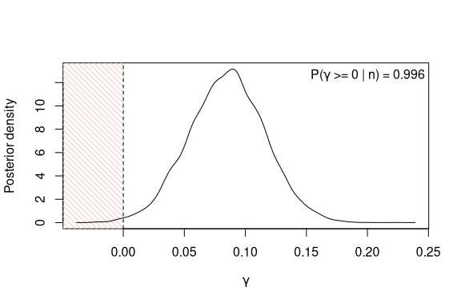

```r
plot(est)
```

The x-axis represents the **rate parameter** $\gamma$. A **positive $\gamma$ indicates an increasing** population trend, while a **negative $\gamma$ indicates a decreasing** trend. The legend in the top corner is added automatically and shows the posterior probability that the population is increasing, based on the observed data (that is, the number of observations/counts, $n$). A narrow, peaked posterior curve indicates high certainty; a flatter curve suggests greater uncertainty and often crosses zero

You can **customize this plot much like a standard scatter plot**. For example, you can remove the legend, change the line color, or provide a custom label for the y-axis:

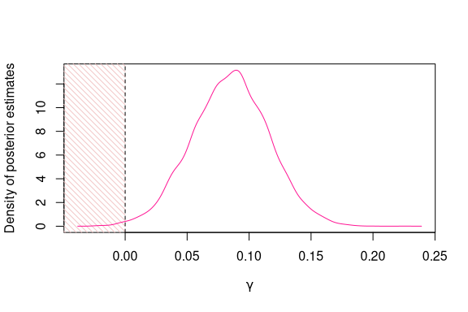

```r
plot(est, col="deeppink", legend=NA, ylab = "Density of posterior estimates")
```

Great, now you know how to **prepare your data**, **fit a simple population trend model** with `birp`, and **understand and visualize the results**. The package also offers more advanced features, including fitting negative binomial and stochastic models, incorporating different sampling designs, modeling multiple time epochs to test for changes in trends, and adding covariates to improve inference. These topics will be covered in the following sections.

# Testing for Changes in Trends Using Sampling Designs

In real-world monitoring, populations often experience **changes in trend** due to interventions, environmental shifts, or other events. The `birp` package **provides flexible tools to test for such changes** using different sampling designs, including:

- **Before-After (BA)**: to assess whether a trend has changed after a certain point in time.
- **Control-Intervention (CI)**: to compare trends between an affected group (intervention) and an unaffected group (control).
- **Before-After-Control-Intervention (BACI)**: a combination of both, allowing to test for intervention effects by comparing groups over time.
- **Step Changes**: to test for sudden shifts in abundance at specific points in time, independently of or in combination with trend changes.

## Before-After (BA) Design: Detecting a Change in Trend Over Time

In some situations, we may suspect that an event (e.g., the establishment of a protected area or arrival of a new predator/disease) has caused a **change in the population trend at a known time**. We can test for this by specifying a **change point** in the `birp()` function using the `timesOfChange` argument:

```r
est <- birp(exampleBirp, verbose = FALSE, timesOfChange = 2023)
print(est)
> Birp estimates:
>  - times of change: [2023]
>  - gamma: [Epoch_2020.000000-2023.000000, Epoch_2023.000000-2024.000000]
>    - Posterior mean of gamma: [0.0315862494993446, 0.259059016625459]
>    - Posterior median of gamma: [0.0308341124865941, 0.259571273002371]
>    - Posterior 5% quantile of gamma: [-0.0454911152749444, 0.0632983652503785]
>    - Posterior 95% quantile of gamma: [0.108916124179331, 0.449730471048915]
>    - Posterior probability of positive P(gamma >= 0): [0.74999, 0.9865]
```

This fits a model that allows **separate trends (gamma ($\gamma$) values) before and after the change point**. The output includes:

- The timepoint of the assumed change (not estimated, but taken from your input).
- **Separate trend estimates** (posterior summaries) for each period (called “epochs”).
- The **probability that the trend is increasing (P($\gamma > 0$)) for each epoch**.

For example, the result:

```
> Posterior probability of increasing trend P(gamma > 0):  0.74999 0.9865
```

## Before-After (BA) Design with or without Step Changes

In some situations, an event may cause not only a change in the population trend, but also a **sudden shift in abundance** at the moment of the event itself. For example, a culling event might immediately reduce population size, after which the population continues to grow or decline at a new rate. `birp` allows you to test for such **step changes** at epoch boundaries alongside trend changes, using two design matrices: `rate_design` and `step_design`.

The `rate_design` matrix defines the trend structure: each row represents a group, and each column after the first (which contains the group name) represents an epoch. The numbers indicate **which trend parameter** ($\gamma$) **to assign** to that group in that epoch. Using the same number in two columns means the trend is assumed to be the same in both epochs; using different numbers allows the trend to differ.

The `step_design` matrix follows the same structure, but instead of assigning trend parameters, it uses **1s and 0s** to indicate whether a step change ($\Delta$) should be estimated at each epoch boundary. A `1` means a step change is estimated, a `0` means it is not. Note that `birp` always defines an epoch boundary at the end of the time series by default, so the final column of step_design controls whether a step change is estimated there too; in most cases you will want to set this to 0.

The `change` argument controls what type of change is modeled at epoch boundaries: - `change = "rate"` (default): only trend changes ($\gamma$) are estimated. - `change = "step"`: only step changes ($\Delta$) are estimated. - `change = "both"`: both trend changes and step changes are estimated simultaneously.

For a single group with one change point where both a trend change and a step change are expected, the two matrices and model call look like this:

```r
rate_design <- matrix(c("Group_1", 1,2), nrow = 1)
print(rate_design)
>      [,1]      [,2] [,3]
> [1,] "Group_1" "1"  "2"
step_design <- matrix(c("Group_1", 1,0), nrow = 1)
print(step_design)
>      [,1]      [,2] [,3]
> [1,] "Group_1" "1"  "0"
```

```r
est <- birp(exampleBirp,
            verbose = FALSE,
            timesOfChange = 2023,
            rate_design = rate_design,
            step_design = step_design,
            change = "both")
print(est)
> Birp estimates:
>  - times of change: [2023]
>  - gamma: [1, 2]
>    - Posterior mean of gamma: [-0.0305429649394091, 0.124502754914689]
>    - Posterior median of gamma: [-0.0312945818129323, 0.123381862293239]
>    - Posterior 5% quantile of gamma: [-0.131181623797414, -0.107267585233552]
>    - Posterior 95% quantile of gamma: [0.0708809276092515, 0.358957285908418]
>    - Posterior probability of positive P(gamma >= 0): [0.3083, 0.81048]
>  - Delta: [1, 0]
>    - Posterior mean of Delta: [0.266067702908813, 0]
>    - Posterior median of Delta: [0.265536983585549, 0]
>    - Posterior 5% quantile of Delta: [-0.0203978302387058, 0]
>    - Posterior 95% quantile of Delta: [0.549075825566289, 0]
>    - Posterior probability of positive P(Delta >= 0): [0.93977, 1]
```

The output includes posterior summaries for both the trend parameters ($\gamma$) and the step change parameter ($\Delta$). Just like the rate change, the step change is estimated on the **log scale**, so the actual multiplicative change in abundance is $\exp^{\Delta}$. A value of $\Delta$=0 means no change, a negative value indicates a sudden decline (e.g., $\Delta$=−1 corresponds to $\exp^{-1}$ = 0.37; a 63% reduction), and a positive value indicates a sudden increase. The posterior probability P(Delta > 0) tells you how confidently the model detects an upward step change.

If you believe the event caused a a change in the underlying trend, but no step change, then use `change = "rate"` and only supply a `rate_design`. Conversely, to only estimate a step change with no change in the underlying trend, then use `change = "step"` and only supply a `step_design`.

It is important to note that choosing between a step change and a rate change is, to some extent, guided by **prior ecological knowledge about the system** under study. For example, if only a step change is included in the model but the true underlying process involves a gradual trend, this trend may be absorbed by the estimated step change. Conversely, if only a rate change is specified, sudden shifts in abundance may be smoothed out over time.

## Control-Intervention (CI) and Before-After-Control-Intervention (BACI) Designs: Comparing Groups

Sometimes, instead of (or in addition to) looking for changes over time, you want to **compare different groups**, for example, a group of locations affected by a policy (**intervention group**) versus unaffected sites (**control group**). This is where **CI** and **BACI** designs come in.

To demonstrate both designs, we first create a dataset with two groups of three sites each, surveyed at irregular timepoints between 2015 and 2026:

```r
exampleBACI <- data.frame(
  location = rep(c("ctrl1", "ctrl2", "ctrl3", "int1", "int2", "int3"), each = 10),
  timepoint = rep(c(2015, 2016, 2018:2024, 2026), times = 6),
  counts = c(
    80, 76, 72, 68, 65, 62, 59, 56, 53, 50,
    60, 57, 54, 51, 49, 46, 44, 42, 40, 38,
    70, 66, 63, 60, 57, 54, 51, 49, 46, 44,
    80, 76, 72, 68, 65, 80, 95, 113, 135, 160,
    60, 57, 54, 51, 49, 60, 72,  86, 103, 123,
    70, 66, 63, 60, 57, 70, 84, 100, 120, 143
  ),
  effort = rep(3, times = 60),
  CI_group = rep(c("Control", "Intervention"), each = 30)
)
birpBACI <- birp_data_from_data_frame(exampleBACI)
```

Note that the years 2017 and 2025 are missing from the survey timepoints; `birp` handles such **irregular and incomplete time series** naturally without requiring any additional steps.

## Control-Intervention (CI) Design

In a **CI design**, we estimate a separate trend for each group across the entire time series, without assuming any change point. The `rate_design` matrix assigns a different $\gamma$ to each group:

```r
rate_design_CI <- matrix(c(
  "Control",      1,
  "Intervention", 2
), nrow = 2, byrow = TRUE)

estCI <- birp(birpBACI,
              change = "rate",
              rate_design = rate_design_CI,
              verbose = FALSE)
print(estCI)
> Birp estimates:
>  - gamma: [1, 2]
>    - Posterior mean of gamma: [-0.0439917363655682, 0.0811618041311225]
>    - Posterior median of gamma: [-0.0439005322358616, 0.081104871981739]
>    - Posterior 5% quantile of gamma: [-0.0559054168178944, 0.0709752381908273]
>    - Posterior 95% quantile of gamma: [-0.0319803529532736, 0.0915714658351001]
>    - Posterior probability of positive P(gamma >= 0): [0, 1]
```

Here, $\gamma_1$ corresponds to the **Control group** and $\gamma_2$ to the **Intervention group**. The model estimates $\gamma_1 =$ -0.04 and $\gamma_2 =$ 0.08, corresponding to $e^{\gamma_1} =$ 0.96 and $e^{\gamma_2} =$ 1.08, which is an approximately **4.3% decline** in the Control group and an approximately **8.5% increase** in the Intervention group per time unit, both with near-certainty (P($\gamma > 0$) = 0 and 1, respectively). This already suggests a clear difference between the two groups, but does not tell us whether this difference arose before or after a specific event.

## Before-After-Control-Intervention (BACI) Design

**BACI** stands for **Before-After-Control-Intervention**, and it is commonly used in environmental impact studies. It **compares trends in control and intervention groups before and after a known event**, allowing us to **test whether the intervention had a measurable effect** while accounting for pre-existing differences between groups.

In a BACI design, the `rate_design` matrix assigns the **same $\gamma$ to both groups before the change point**, and a **separate $\gamma$ only to the intervention group after the change point**:

```r
rate_design_BACI <- matrix(c(
  "Control",      1, 1,
  "Intervention", 1, 2
), nrow = 2, byrow = TRUE)

est_BACI <- birp(birpBACI,
                 change = "rate",
                 rate_design = rate_design_BACI,
                 timesOfChange = 2020,
                 verbose = FALSE)
print(est_BACI)
> Birp estimates:
>  - times of change: [2020]
>  - gamma: [1, 2]
>    - Posterior mean of gamma: [-0.041863210730276, 0.158842731699702]
>    - Posterior median of gamma: [-0.0417988338425033, 0.158960223951911]
>    - Posterior 5% quantile of gamma: [-0.049832823124569, 0.144126487508428]
>    - Posterior 95% quantile of gamma: [-0.0338618372625345, 0.173167903093818]
>    - Posterior probability of positive P(gamma >= 0): [0, 1]
```

Here, $\gamma_1$ is the **shared trend before 2020** (and the control group’s trend throughout), and $\gamma_2$ is the **intervention group’s trend after 2020**; this is our parameter of primary interest. The model estimates $\gamma_1 =$ -0.04 ($e^{\gamma_1} =$ 0.96, a **4.1% decline** per time unit) and $\gamma_2 =$ 0.16 ($e^{\gamma_2} =$ 1.17, a **17.2% increase** per time unit). With P($\gamma_2 > 0$) = 1, the model is highly confident that the intervention group shifted to a positive trend after 2020, providing **strong evidence for a positive intervention effect**.

To see these results visually, you can plot the posterior trend estimates of both rate parameters:

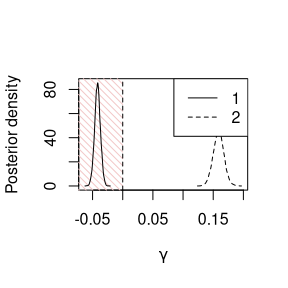

```r
plot(est_BACI)
```

This plot shows the posterior distributions of $\gamma_1$ and $\gamma_2$ side by side. It clearly shows that $\gamma_1$ is estimated to be negative, reflecting the shared declining trend before 2020 and the control group throughout, while $\gamma_2$ is positive, confirming the shift to an increasing trend in the intervention group after 2020. The narrowness of both distributions reflects the certainty of these estimates, the more narrow the peak, the more certain the model is. A different way to visualise the results will be covered below

## Summary

Whether you’re testing for a **temporal shift in trend**, a **difference between groups**, or a **combination of both**, `birp` gives you the flexibility to model:

- Single or multiple change points.
- Control vs intervention groups.
- Interactions between time and group (BACI).

Just like in the single-epoch example, `birp` includes **built-in plotting functions to visualize the results of a multi-epoch model**:

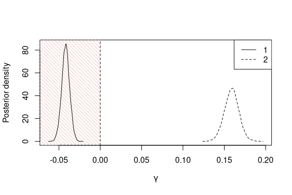

```r
plot(est_BACI)
```

There is another function called `plot_epoch_pair`, that can be used to get a **two-dimensional plot** of epoch pairs:

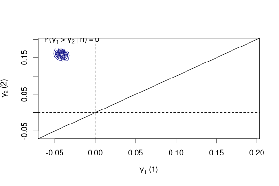

```r
plot_epoch_pair(est_BACI, col="navy")
```

In this plot, the **trend estimate for the first epoch ($\gamma_1$) is shown on the x-axis**, and the **estimate for the second epoch ($\gamma_2$) on the y-axis**. Dashed lines mark zero on both axes, dividing the plot into four quadrants. Posterior densities are visualized as circles, where **smaller circles indicate higher certainty** and larger circles reflect greater uncertainty. In this example, the model is confident in its estimates, as shown by the relatively small circle.

The **location of the posterior density within a quadrant reveals the direction of the estimated trends**:

- Top-left quadrant: $\gamma_1$ is negative, $\gamma_2$ is positive - a decline followed by an increase (our case).
- Top-right quadrant: both $\gamma_1$ and $\gamma_2$ are positive - consistent increase across both epochs.
- Bottom-left quadrant: both $\gamma_1$ and $\gamma_2$ are negative - consistent decline across both epochs.
- Bottom-right quadrant: $\gamma_1$ is positive, $\gamma_2$ is negative - an increase followed by a decline.

This visual summary allows **quick interpretation of both the direction and certainty of multi-epoch trends**.

# Combining multiple survey methods

In many ecological studies, population trends are inferred from data collected using **multiple methods** such as camera traps, track counts, acoustic detectors, or field observations. `birp` supports such **multi-method data sets**, allowing you to **integrate counts from different sources to improve inference** and account for method-specific variation in detection probabilities or survey effort.

To use multiple methods in `birp`, you need to **provide a separate data set for each method**. Each data set should follow the **standard `birp` data format** (see the Input Data Format).

This vignette includes two example data sets, one from a camera trap study and the other from a track count study, both conducted for the same species and at the same locations. To **read in both files and estimate population trends using both data sets simultaneously**, use the following code:

```r
# Access the path to the example data provided with the package
pathToFiles <- system.file("extdata", package = "birp")

# Read in both files
data <- birp_data_from_file(filenames = c(
  file.path(pathToFiles, "cameraTrapData.csv"),
  file.path(pathToFiles, "trackData.csv")
))
```

**What is** `system.file()`?

The function `system.file()` is **not part of the** `birp` **package**, but a **base R utility** that returns the path to files included with any installed R package. This makes your code **reproducible and portable**, since the file paths will work regardless of where the package is installed on a user’s system.

**Using your own data**

If you have your own data sets stored elsewhere on your computer, **you don’t need `system.file()`**. Just **provide the full path to each file directly**:

```r
data <- birp_data_from_file(filenames = c(
  "path/to/your/file/cameraTrapData.csv",
  "path/to/your/file/trackData.csv"
))
```

Now that you converted your input files into birp-objects using the `birp_data_from_file()` function (or any of the other available functions), you can fit the model in the same way as above; `birp` will automatically take into account the data from both survey methods and estimate the population trend form them:

```r
estMultiMethod <- birp(data, verbose=FALSE)
print(estMultiMethod)
> Birp estimates:
>  - gamma: [Epoch_2010.000000-2025.000000]
>    - Posterior mean of gamma: [0.0453290621730774]
>    - Posterior median of gamma: [0.0453306590301339]
>    - Posterior 5% quantile of gamma: [0.0439442601883559]
>    - Posterior 95% quantile of gamma: [0.0467118239633248]
>    - Posterior probability of positive P(gamma >= 0): [1]
```

The model estimates a positive trend with high certainty.

# Running a Negative-Binomial Model

By default, `birp` assumes that the counts follow a **Poisson distribution**. However, if **overdispersion is suspected**, meaning the **variance in the data exceeds the mean**, a negative binomial model may be more appropriate. You can **switch to a negative binomial likelihood** by setting the argument `negativeBinomial = TRUE` while keeping the rest of the model setup unchanged. Let’s run it using the same example data as above:

```r
exampleData <- data.frame(
  location = rep(c("site1", "site2", "site3"), each = 5),
  timepoint = rep(2020:2024, times = 3),
  counts    = c(28, 12, 26, 48, 20, 21, 22, 76, 22, 100, 65, 32, 60, 19, 42),
  effort   = c(2,1,2,3,1,1,1,4,1,4,5,2,5,1,2),
  CI_group    = rep("Group_1", times = 15)
)
exampleBirp <- birp_data_from_data_frame(exampleData)
fit_nb <- birp(data = exampleBirp,
               negativeBinomial = TRUE,
               verbose = FALSE)
print(fit_nb)
> Birp estimates:
>  - gamma: [Epoch_2020.000000-2024.000000]
>    - Posterior mean of gamma: [0.0873595355927029]
>    - Posterior median of gamma: [0.0872932045282261]
>    - Posterior 5% quantile of gamma: [0.0248894113783513]
>    - Posterior 95% quantile of gamma: [0.152484873622525]
>    - Posterior probability of positive P(gamma >= 0): [0.98571]
```

This will fit the same single-epoch model as above, but now the **likelihood allows for overdispersed count data**. Because the model estimates one additional parameter (the **overdispersion parameter** `b`), it is slightly less certain (98.57%) about the trend estimates, resulting in a **slightly reduced statistical power**.

## Deciding between Poisson or Negative-binomial

To help determine whether the **negative binomial (NB) model is necessary**, we provide the function `assess_NB()`. This function evaluates whether the **additional flexibility of the NB model is warranted by the data** or whether a **simpler Poisson model would be enough**. It does this by **repeatedly simulating new datasets under a Poisson assumption** and comparing the fit against the original NB model fit. If the Poisson model consistently performs worse, `assess_NB()` recommends keeping the NB model. Otherwise, it suggests switching to the Poisson model to improve statistical power. For example:

```r
exampleBirp <- birp_data_from_data_frame(exampleData)
est <- birp(exampleBirp, negativeBinomial = TRUE, verbose=FALSE)
res_assess <- assess_NB(est, numRep = 100, verbose=FALSE)
```

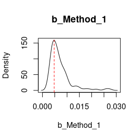

```
> Could not reject null hypothesis (Poisson) with for all methodsMethod_1with p-values0.66. It is recommended to rerun birp under the Poisson model (negativeBinomial = FALSE) to gain power.
```

If `res_assess$keepNB` is `TRUE`, the data is **considered overdispersed**, and the **NB model should be retained**. If it is `FALSE`, the **Poisson model is preferred**. By default, `plot = TRUE` generates a visual inspection of the distribution of the overdispersion parameter (b) across replicates; set it to `FALSE` to suppress the plot. In this example, the results suggest that the **Poisson model provides an adequate fit**, and using the more complex negative binomial model is unnecessary.

# Fitting a Stochastic Trend Model

The default trend model in `birp` is **deterministic**, meaning that within each epoch the population is assumed to follow an exact exponential trend defined by the parameter $\gamma$. To account for **random fluctuations in population size between locations**, you can instead use a *stochastic trend model* by setting `stochastic = TRUE`:

```r
exampleBirp <- birp_data_from_data_frame(exampleData)
fit_stoch <- birp(data = exampleBirp,
                  stochastic = TRUE,
                  verbose = FALSE)
```

This allows for **location-specific fluctuations around the shared group-level trend**, providing a more flexible model for populations with variable dynamics across sites. See the final section of this vignette for additional information about the modeling process.

# Using additional covariates

A standard `birp` analysis requires only one covariate column: the **effort covariate**. In addition to the required effort covariate, `birp` also supports **optional detection covariates**. These covariates are used to **model variation in detection probabilities across time or space**. By default, `birp` assumes detection probability is constant within each method-location pair across time, which means that detection probabilities cancel out of the model. However, if you **suspect that detection probability varies** (e.g., with time of day, season, or observer), you can **include one or more detection covariates**.

**Detection covariate columns** in the input file must be named `covDetection_1`, `covDetection_2`, and so on.

## Example: Adding a Detection Covariate

Below is an example of a data frame that includes one detection covariate, in addition to the required columns:

```r
detectionExample_data <- data.frame(
  location  = rep(c("site1", "site2"), each = 5),
  timepoint = rep(2015:2019, times = 2),
  counts    = sample(10:100, 10, replace = TRUE),
  effort    = sample(1:5, 10, replace = TRUE),
  CI_group  = rep("Group_1", 10),
  covDetection_1 = runif(10, 0, 1)      # random values between 0 and 1
)
```

Lets covert to a `birp data` object:

```r
detectionBirp <- birp_data_from_data_frame(detectionExample_data)
```

You can now **estimate the trend using the `birp()` function**. If you believe the detection covariate reflects the **actual detection probability** (i.e., it is known rather than estimated), you can set `assumeTrueDetectionProbability = TRUE`. This option is **only available when there is a single detection covariate**.

```r
detectionEst <- birp(detectionBirp, assumeTrueDetectionProbability=FALSE, verbose = FALSE)
```

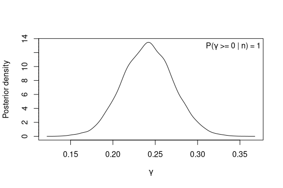

```r
plot(detectionEst)
```

## Additional covariates vs stratifying your data

While `birp` allows you to model detection probabilities using covariates, there is an **alternative approach** that can often be **more effective: stratification**.

Stratification means **dividing your data into separate survey methods** based on known factors that influence detection probability, such as the **observer**, **time of day**, or **equipment type**, and **treating each stratum as a distinct method** in the analysis (see Combining Multiple Survey Methods).

For example:

- If **two different observers** contributed to the data collection, you can create two different data sets, one for “observer1” and one for “observer2”.
- If you are using camera traps and have **day-time color images and night-time black-and-white images**, these could be treated as two separate methods (e.g., `method = "day"` and `method = "night"`).

Whenever feasible, we **recommend using stratification** rather than modeling detection through covariates. This is because **estimating detection probabilities from covariates adds complexity to the model and often reduces statistical power**.

# Simulating Example Data

To explore how `birp` works, you can **generate simulated data** using the `simulate_birp()` function. This is especially useful for **learning, testing model behavior, or evaluating performance under known parameter values**.

The following example simulates count data for a population that **declines before 2010 and increases afterward**. The population trend is determined by two $\gamma$ values: $-0.03$ before 2010 and $0.03$ after.

```r
simData <- simulate_birp(gamma = c(-0.03, 0.03),
                      timepoints = 2000:2020,
                      timesOfChange = 2010,
                      verbose = FALSE)
```

This creates a `birp_data` **object containing the simulated counts and associated timepoints**, which can be used as input to the `birp` function just like above:

```r
est <- birp(simData, verbose=FALSE, timesOfChange = 2010)
print(est)
> Birp estimates:
>  - times of change: [2010]
>  - gamma: [Epoch_2000.000000-2010.000000, Epoch_2010.000000-2020.000000]
>    - Posterior mean of gamma: [-0.0292554151743314, 0.0280666724834436]
>    - Posterior median of gamma: [-0.0292468583273275, 0.0280556646213087]
>    - Posterior 5% quantile of gamma: [-0.0319393536388635, 0.025206256870798]
>    - Posterior 95% quantile of gamma: [-0.0266228711987794, 0.0310629401765701]
>    - Posterior probability of positive P(gamma >= 0): [0, 1]
```

In this case, `birp` is sure that the trend **increases after 2010 and decreases before 2010**.

# Overview of the `birp` modeling framework

Our modeling framework builds on **classic count distributions (Poisson and negative binomial)** and **explicitly tests for changes in population trends over predefined time epochs**.

## 1. Population Trend Models

We implement two variants of population trend models: a **deterministic model** and a **stochastic model**. Both models describe how population abundance evolves exponentially over time but differ in their assumptions about spatial variation among locations. The structure of the models is flexible enough to represent **classical study designs like Before-After (BA) or Before-After-Control-Intervention (BACI)**, as well as more complex combinations of groups and time periods.

In addition to gradual changes in growth rates, the framework also allows for instant step changes between epochs, capturing sudden shifts in population size (e.g. due to a catastrophic event).

Since the model tracks **relative abundances**, it tells us how populations have changed **compared to the first survey**, but not their absolute size (i.e., the total number of individuals).

### Deterministic Model

In the **deterministic approach**, populations at each location belong to groups sharing a **common trend**. We partition the overall study period into a number of epochs (specified by the user and it can be just a single epoch), separated at known times.

Within each epoch, the population changes exponentially at a **constant rate** $\gamma(g,m)$, where the rate is specific to a species group $g$ and epoch $m$. In addition, we allow for instantaneous step changes $\Delta(g,m)$ at the boundaries between epochs, which represent sudden proportional changes in population size.

The relative abundance at location $j$ and survey time $t_k$ is given by:

$$\varphi_j(t_k, \boldsymbol{\theta}) =
\exp \left(
\sum_{m=1}^M \rho_m(t_k)\, \gamma(g(j), m)
+
\sum_{m=1}^M \mathbb{I}(t_k \geq T_m)\, \Delta(g(j), m)
\right)$$

Here’s what each part means:

- $\gamma(g(j), m)$ is the **population growth rate** for group $g(j)$ during epoch $m$.
- $\Delta(g(j), m)$ is a step change at time $T_m$.
- $\rho_m(t_k)$ is a **weighting factor** that represents how much of epoch $m$ has passed by time $t_k$.
- $\boldsymbol{\theta}$ is the **vector of all model parameters**, i.e. $\boldsymbol{\theta} = (\boldsymbol{\gamma}, \boldsymbol{\Delta})$, combining growth rates and step changes; quantities such as $\rho_m(t_k)$ are deterministic functions of time and not estimated
- The sum over all epochs allows the model to **combine multiple time periods with different growth rates**.
- The exponential function reflects the assumption of **exponential growth (or decline)** within each epoch.

In other words, the deterministic model assumes that **populations within the same group follow identical trajectories**, fully determined by shared growth rates and step changes.

### Stochastic Model

Population changes may not always follow smooth, predictable patterns. Even if two locations belong to the same group and share similar environmental conditions, their populations might grow or decline differently due to chance events, like a sudden storm or disease outbreak. To reflect this kind of randomness, we extend the deterministic model by adding **stochasticity**, allowing for **random fluctuations over time** as well as variability in step changes.

We model these fluctuations using a process known as **geometric Brownian motion**, which is a standard way to model quantities that grow or shrink randomly over time. In this framework, the relative abundance $\tilde{\varphi}_j(t, \boldsymbol{\theta})$ at location $j$ evolves according to:

$$\mathrm{d} \tilde{\varphi}_j(t, \boldsymbol{\theta}) = \gamma_{g(j)}(t)
\tilde{\varphi}_j(t, \boldsymbol{\theta}) \, \mathrm{d}t + \sigma
\tilde{\varphi}_j(t, \boldsymbol{\theta}) \, \mathrm{d}W(t),$$

The only additional parameter in this equation is the volatility parameter $\sigma$, which represents the randomness.

Here’s what each part means:

- $\gamma_{g(j)}(t)$ represents the **average growth** rate for the group that location $j$ belongs to.
- $\sigma$ is a parameter that **controls how ‘noisy’ or unpredictable the changes are**; larger values mean more variation.
- $W(t)$ represents **random noise over time**, modeled as Brownian motion.
- The multiplication by $\tilde{\varphi}_j(t, \boldsymbol{\theta})$ ensures that **locations with larger populations experience proportionally larger changes**, both in the deterministic and the random parts of the equation.

We also allow step changes to vary across locations:
$$\Delta_{jm} \sim \mathcal{N}\left(\Delta(g(j), m), \; \zeta(g(j),m)\,
\sigma^2 \right)$$

This means that:

- $\Delta(g(j), m)$ is the **average (group-level) step change** between epochs
- $\Delta_{jm}$ is the **realized step change at location $j$**, which may differ from the average
- $\zeta(g(j),m)$ controls how much **variation there is in step changes across locations**

In other words, while all locations in a group share the same *expected* sudden change, the actual magnitude of that change can differ due to randomness.

To summarise, in the stochastic model, **each location tends to follow the group’s average trend, but with some randomness on top**. Some locations might temporarily grow faster or slower just due to chance.

## 2. Observation Model

So far, we have described how populations are expected to change over time at each location. But what we actually observe are **counts**, which are the number of individuals recorded during a survey. These observed counts depend not only on how many individuals are present, but also on **how much effort** was put into the survey (e.g., how long someone looked, or how many traps were used) and **how likely individuals were to be detected**.

We model the observed counts $n_{ijk}$ from survey method $i$, location $j$, and time $t_k$ as being drawn from either a **Poisson** or **Negative Binomial** distribution, depending on how much variation is expected in the data:

$$n_{ijk} \sim \text{Poisson}(\lambda_{ij}(t_k) \, s_{ijk})
\quad \text{or} \quad
n_{ijk} \sim \text{NegativeBinomial}(\lambda_{ij}(t_k) \, s_{ijk},
\theta)$$

Here’s what these models mean:

- The **Poisson distribution** assumes that counts vary randomly around a mean (the expected count), with **variance equal to the mean**.
- The **Negative Binomial distribution** allows for **extra variability**, which is common in ecological count data; this is controlled by the parameter $\theta$.
- $\lambda_{ij}(t_k)$ is the **observation rate**: the expected number of individuals observed per unit of effort.
- $s_{ijk}$ is the **effort**, provided by the user (e.g., trap-nights, survey hours, etc.).

The observation rate is modeled as:

$$\lambda_{ij}(t_k) = N_{j T_0} \, \varphi_j(t_k, \boldsymbol{\theta}) \,
\delta_{ij}$$

This combines information about the population and the observation process:

- $N_{j T_0}$ is the **initial abundance** at location $j$ at the first survey time.
- $\varphi_j(t_k, \boldsymbol{\theta})$ is the **relative abundance** at time $t_k$, modeled using the deterministic or stochastic population trend, including both gradual changes (growth rates) and sudden step changes between epochs.
- $\delta_{ij}$ is the **detection probability**, describing how likely an individual is to be seen using method $i$ at location $j$.

In our model, we often **do not need to estimate the initial population size $N$ or the detection probability $\delta$**. This is because we **condition on the total number of counts**, which means we focus only on the **relative proportions of observations rather than their absolute values**. As a result, the terms for population size and detection probability effectively cancel out. If you would like to read more about this, please refer to the [manuscript](https://www.biorxiv.org/content/10.1101/2025.01.08.631844v1).

In short, the observation model **connects what we expect based on population trends to what we actually observe in the field**, accounting for survey effort, detection probability, and variability in the data.